# SC2 KR Grandmaster January 2016

# 1 Introduction

Data taken from the Korean Starcraft 2 grandmaster league January 2016.

### 1.1 Loading libraries

Let’s load the libraries we will be using and load our data

```r
#libraries
library(dplyr)
library(tidyr)
library(ggplot2)
library(ggthemes)
library(gridExtra)
```

### 1.2 Initial observations

Let’s take a quick peek using head and str()

```r
head(sc)
```

```
## Source: local data frame [6 x 21]
##
##   P.RANK PvP.Win PvP.Loss PvT.Win PvT.Loss PvZ.Win PvZ.Loss Z.RANK ZvP.Win
##    (int)   (int)    (int)   (int)    (int)   (int)    (int)  (int)   (int)
## 1      1      87       49     115       41     106       41      2     347
## 2      3     195      130     213       78     154      150      8     334
## 3      5     132       62     117       43     114       52     17     220
## 4      6     132       83     140       79     107       92     20     213
## 5      7     173      100     192       63     157      109     25     226
## 6      9     318      151     339      132     296      173     26     166
## Variables not shown: ZvP.Loss (int), ZvT.Win (int), ZvT.Loss (int),
##   ZvZ.Win (int), ZvZ.Loss (int), T.RANK (int), TvP.Win (int), TvP.Loss
##   (int), TvT.Win (int), TvT.Loss (int), TvZ.Win (int), TvZ.Loss (int)
```

```r
str(sc)
```

```
## Classes 'tbl_df', 'tbl' and 'data.frame':    60 obs. of  21 variables:
##  $ P.RANK  : int  1 3 5 6 7 9 10 11 12 13 ...
##  $ PvP.Win : int  87 195 132 132 173 318 208 114 115 84 ...
##  $ PvP.Loss: int  49 130 62 83 100 151 137 73 83 37 ...
##  $ PvT.Win : int  115 213 117 140 192 339 181 116 170 90 ...
##  $ PvT.Loss: int  41 78 43 79 63 132 122 52 66 17 ...
##  $ PvZ.Win : int  106 154 114 107 157 296 216 127 107 65 ...
##  $ PvZ.Loss: int  41 150 52 92 109 173 158 54 106 20 ...
##  $ Z.RANK  : int  2 8 17 20 25 26 28 29 31 32 ...
##  $ ZvP.Win : int  347 334 220 213 226 166 296 299 84 206 ...
##  $ ZvP.Loss: int  169 123 114 105 83 91 172 187 44 146 ...
##  $ ZvT.Win : int  304 310 195 212 141 185 248 319 86 200 ...
##  $ ZvT.Loss: int  247 133 123 127 115 118 168 226 57 167 ...
##  $ ZvZ.Win : int  293 246 170 185 161 183 174 252 69 234 ...
##  $ ZvZ.Loss: int  156 108 95 107 80 74 115 200 60 130 ...
##  $ T.RANK  : int  4 14 15 16 23 24 27 34 35 36 ...
##  $ TvP.Win : int  135 87 55 88 202 249 38 50 180 88 ...
##  $ TvP.Loss: int  86 73 32 61 170 198 46 33 142 89 ...
##  $ TvT.Win : int  148 82 63 87 210 280 62 90 214 130 ...
##  $ TvT.Loss: int  57 46 22 45 123 152 28 31 113 73 ...
##  $ TvZ.Win : int  145 134 75 89 202 284 63 66 219 108 ...
##  $ TvZ.Loss: int  40 46 15 40 107 144 19 35 111 76 ...
```

The data is sorted by Race rank and their resprective matchups.  
Let’s reorder the columns by the player races.

```r
sc <- sc[, c(1, 8, 15, 2:7, 9:14, 16:21)]
head(sc)
```

```
## Source: local data frame [6 x 21]
##
##   P.RANK Z.RANK T.RANK PvP.Win PvP.Loss PvT.Win PvT.Loss PvZ.Win PvZ.Loss
##    (int)  (int)  (int)   (int)    (int)   (int)    (int)   (int)    (int)
## 1      1      2      4      87       49     115       41     106       41
## 2      3      8     14     195      130     213       78     154      150
## 3      5     17     15     132       62     117       43     114       52
## 4      6     20     16     132       83     140       79     107       92
## 5      7     25     23     173      100     192       63     157      109
## 6      9     26     24     318      151     339      132     296      173
## Variables not shown: ZvP.Win (int), ZvP.Loss (int), ZvT.Win (int),
##   ZvT.Loss (int), ZvZ.Win (int), ZvZ.Loss (int), TvP.Win (int), TvP.Loss
##   (int), TvT.Win (int), TvT.Loss (int), TvZ.Win (int), TvZ.Loss (int)
```

Still doesn’t look very good. We’ll have to use tidyr to restructure the dataset to make it more readable.

# 2 Data cleaning

We will use the package tidyr’s gather() to turn the data into a more readable format.

### 2.1 Feature cleaning

In order to create a new column for player’s race and opponents race we’ll create a list of matchups.

```r
pc <- c("PvP", "PvZ", "PvT")
zc <- c("ZvP", "ZvZ", "ZvT")
tc <- c("TvP", "TvZ", "TvT")

cp <- c("PvP", "TvP", "ZvP")
cz <- c("PvZ", "TvZ", "ZvZ")
ct <- c("PvT", "TvT", "ZvT")
```

### 2.2 Player’s race

Let’s map the user race and create a new column called Race

```r
sc <-
sc %>%
  gather(matchup, wins, -(1:3)) %>%
  separate(matchup, c("Matchup", "Result"), sep = "\\.") %>%
  mutate(
    Race = ifelse(Matchup %in% pc, "Protoss",
           ifelse(Matchup %in% zc, "Zerg", "Terran"))
      )
```

### 2.3 Opponents race

We’ll do the same thing this time but with their opponent’s race

```r
sc <-
sc %>%
  mutate(
    Opponent = ifelse(Matchup %in% cp, "Protoss",
               ifelse(Matchup %in% cz, "Zerg", "Terran"))
  )
```

### 2.4 Finalizing cleaning

We’ll have to do some more tidying in order to put all placements in the same column

```r
sc <-
sc %>%
  gather(Rank, Placement, 1:3) %>%
  select(7, 6, 1:5)
```

Now lets see what our data looks like.

```r
sc <-
sc %>%
  mutate(
    Rank = ifelse(Rank == "P.RANK", "Protoss",
           ifelse(Rank == "Z.RANK", "Zerg", "Terran"))
  )

sc
```

```
## Source: local data frame [3,240 x 7]
##
##    Placement    Rank Matchup Result  wins    Race Opponent
##        (int)   (chr)   (chr)  (chr) (int)   (chr)    (chr)
## 1          1 Protoss     PvP    Win    87 Protoss  Protoss
## 2          3 Protoss     PvP    Win   195 Protoss  Protoss
## 3          5 Protoss     PvP    Win   132 Protoss  Protoss
## 4          6 Protoss     PvP    Win   132 Protoss  Protoss
## 5          7 Protoss     PvP    Win   173 Protoss  Protoss
## 6          9 Protoss     PvP    Win   318 Protoss  Protoss
## 7         10 Protoss     PvP    Win   208 Protoss  Protoss
## 8         11 Protoss     PvP    Win   114 Protoss  Protoss
## 9         12 Protoss     PvP    Win   115 Protoss  Protoss
## 10        13 Protoss     PvP    Win    84 Protoss  Protoss
## ..       ...     ...     ...    ...   ...     ...      ...
```

By using gather() we have stacked placemens all in one column. As a result of that we are going to have some duplicate rows. We will remove them by mapping our hew Race column with our relabeled Rank column.

```r
sc <-
sc %>%
  filter(Rank == Race) %>%
  arrange(Placement)
```

Some clean up work to fix a few variable classes as well as column arrangement

```r
sc <-
sc %>%
  select(-Race) %>%
  select(Placement, Rank, Opponent, Matchup, Result, wins) %>%
  rename(Race = Rank,
         Count = wins) %>%
  mutate_each(funs(as.factor),
              c(Race,
                Opponent,
                Matchup,
                Result)
              )
```

### 2.4 Cleanup complete

Let’s check our work before proceeding

```r
sc %>%
  print(n=30)
```

```
## Source: local data frame [1,080 x 6]
##
##    Placement    Race Opponent Matchup Result Count
##        (int)  (fctr)   (fctr)  (fctr) (fctr) (int)
## 1          1 Protoss  Protoss     PvP    Win    87
## 2          1 Protoss  Protoss     PvP   Loss    49
## 3          1 Protoss   Terran     PvT    Win   115
## 4          1 Protoss   Terran     PvT   Loss    41
## 5          1 Protoss     Zerg     PvZ    Win   106
## 6          1 Protoss     Zerg     PvZ   Loss    41
## 7          2    Zerg  Protoss     ZvP    Win   347
## 8          2    Zerg  Protoss     ZvP   Loss   169
## 9          2    Zerg   Terran     ZvT    Win   304
## 10         2    Zerg   Terran     ZvT   Loss   247
## 11         2    Zerg     Zerg     ZvZ    Win   293
```

[output cut: 20 more lines]

# 3 Observations

We’ll create a new variable sc2 just in case we need to revert back to sc.

```r
sc2 <-
sc
```

### 3.1 Individual player win/loss percentages

Here we have a list of win/loss rate based on individual players and their matchups.

```r
by.player <-
sc2 %>%
  group_by(Placement, Race, Opponent) %>%
  mutate(
    Percentage = round(Count / sum(Count), 2)
  )

by.player
```

```
## Source: local data frame [1,080 x 7]
## Groups: Placement, Race, Opponent [540]
##
##    Placement    Race Opponent Matchup Result Count Percentage
##        (int)  (fctr)   (fctr)  (fctr) (fctr) (int)      (dbl)
## 1          1 Protoss  Protoss     PvP    Win    87       0.64
## 2          1 Protoss  Protoss     PvP   Loss    49       0.36
## 3          1 Protoss   Terran     PvT    Win   115       0.74
## 4          1 Protoss   Terran     PvT   Loss    41       0.26
## 5          1 Protoss     Zerg     PvZ    Win   106       0.72
## 6          1 Protoss     Zerg     PvZ   Loss    41       0.28
## 7          2    Zerg  Protoss     ZvP    Win   347       0.67
## 8          2    Zerg  Protoss     ZvP   Loss   169       0.33
## 9          2    Zerg   Terran     ZvT    Win   304       0.55
## 10         2    Zerg   Terran     ZvT   Loss   247       0.45
## ..       ...     ...      ...     ...    ...   ...        ...
```

### 3.2 Matchup winrates

Another list but based on specific matchups

```r
by.matchup <-
sc2 %>%
  group_by(Race, Opponent, Result) %>%
  summarise(
    Count = sum(Count)
  ) %>%
  mutate(
    percent = round(Count / sum(Count),2)
  ) %>%
  arrange(desc(Result))

wins.by.matchup <-
by.matchup %>%
  filter(Result == "Win")

wins.by.matchup
```

```
## Source: local data frame [9 x 5]
## Groups: Race, Opponent [9]
##
##      Race Opponent Result Count percent
##    (fctr)   (fctr) (fctr) (int)   (dbl)
## 1 Protoss  Protoss    Win  6829    0.56
## 2 Protoss   Terran    Win  9218    0.64
## 3 Protoss     Zerg    Win  7308    0.55
## 4  Terran  Protoss    Win  5661    0.52
## 5  Terran   Terran    Win  7922    0.59
## 6  Terran     Zerg    Win  7656    0.62
## 7    Zerg  Protoss    Win  7475    0.60
## 8    Zerg   Terran    Win  8206    0.56
## 9    Zerg     Zerg    Win  7796    0.58
```

Wins by matchup

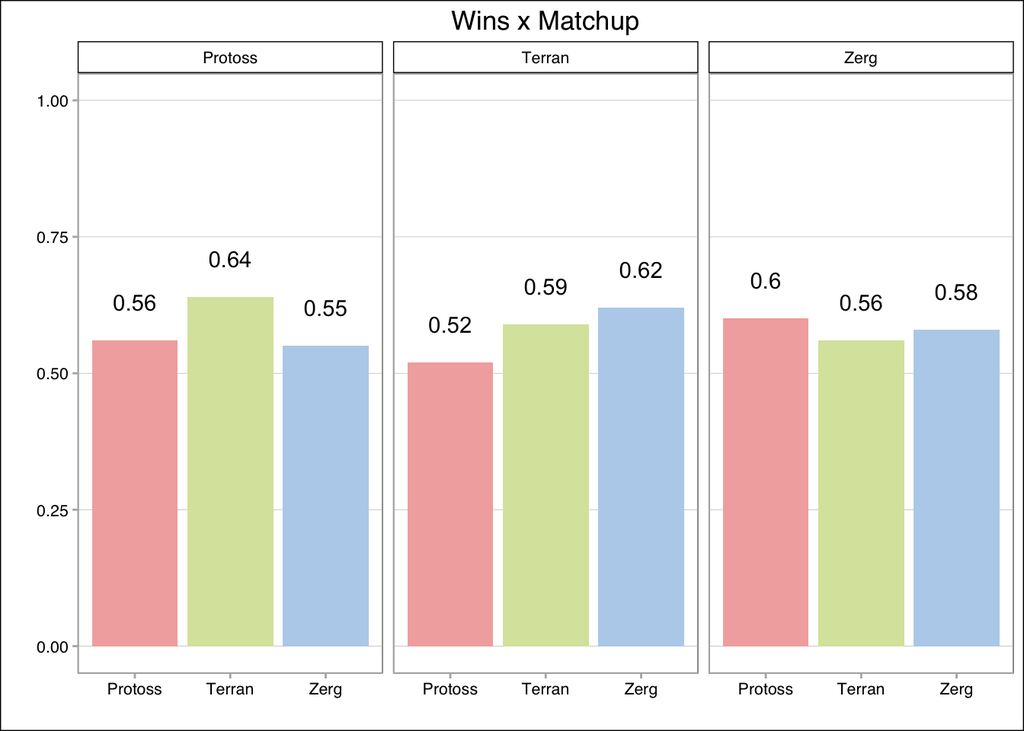

```r
ggplot(wins.by.matchup, aes(x = Opponent, y = percent, label = percent,
                            fill = Opponent)) +
  geom_bar(stat = "identity") +
  facet_grid(~Race) +
  theme_calc() +
  scale_fill_few() +
  expand_limits(y = c(0,1)) +
  geom_text(nudge_y = .07) +
  ggtitle("Wins x Matchup") +
  xlab("") +
  ylab("") +
  guides(fill = FALSE) +
  theme(
    panel.grid.major = element_line(size = .1)
  )
```

### 3.3 Race winrates

Last breakdown based on race

```r
by.race <-
sc2 %>%
  group_by(Race, Result) %>%
  summarise(
    Count = sum(Count)
  ) %>%
  mutate(
    percent = round(Count / sum(Count),2)
  ) %>%
  arrange(desc(Result))

wins.by.race <-
  by.race %>%
  filter(Result == "Win")

wins.by.race
```

```
## Source: local data frame [3 x 4]
## Groups: Race [3]
##
##      Race Result Count percent
##    (fctr) (fctr) (int)   (dbl)
## 1 Protoss    Win 23355    0.59
## 2  Terran    Win 21239    0.58
## 3    Zerg    Win 23477    0.58
```

Here is the highest level: wins based on player race.

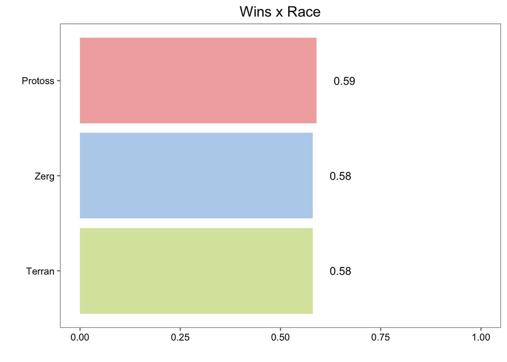

```r
ggplot(wins.by.race, aes(x = reorder(Race, percent), y = percent,
                         label=percent, fill = as.factor(Race))) +
  geom_bar(stat = "identity") +
  theme_few() +
  scale_fill_few() +
  expand_limits(y = c(0,1)) +
  coord_flip() +
  geom_text(nudge_y = .07) +
  ggtitle("Wins x Race") +
  xlab("") +
  ylab("") +
  guides(fill = FALSE)
```

# 4 Placement

### 4.1 Top 10

What races are represented in the top 10?

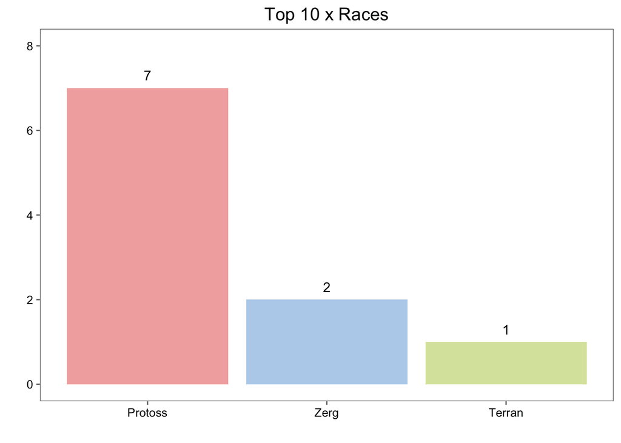

```r
top10 <-
  sc2 %>%
  distinct(Placement) %>%
  group_by(Race) %>%
  filter(Placement <= 10) %>%
  summarise(
    Count = n()
  )

ggplot(top10, aes(x = reorder(Race, -Count ), y = Count, label = Count)) +
  geom_bar(aes(fill = Race), stat = "identity") +
  expand_limits(y = c(0,8)) +
  theme_few() +
  scale_fill_few() +
  guides(fill = FALSE) +
  xlab("") +
  ylab("") +
  ggtitle("Top 10 x Races") +
  geom_text(nudge_y = .3)
```

### 4.2 Top 150 breakdown

A huge majority is representing Protoss. Let’s check if this is different for the other ranks. Let’s compare the top 50, 51-100, 101~150 race selections.

```r
top50 <-
  sc2 %>%
  distinct(Placement) %>%
  group_by(Race) %>%
  filter(Placement <= 50) %>%
  summarise(
    Count = n()
  )

top50.plot <-
  ggplot(top50, aes(x = reorder(Race, -Count ), y = Count, label = Count)) +
  geom_bar(aes(fill = Race), stat = "identity") +
  expand_limits(y = c(0,8)) +
  theme_few() +
  scale_fill_few() +
  guides(fill = FALSE) +
  xlab("") +
  ylab("") +
  ggtitle("Top 50") +
  geom_text(nudge_y = .8) +
  theme(
    axis.ticks.y = element_blank(),
    axis.text.y = element_blank()
  )

#51-100
top51.100 <-
  sc2 %>%
  distinct(Placement) %>%
  group_by(Race) %>%
  filter(Placement > 50 & Placement <= 100) %>%
  summarise(
    Count = n()
  )

top51.100.plot <-
  ggplot(top51.100, aes(x = reorder(Race, -Count ), y = Count, label = Count)) +
  geom_bar(aes(fill = Race), stat = "identity") +
  expand_limits(y = c(0,8)) +
  theme_few() +
  scale_fill_few() +
  guides(fill = FALSE) +
  xlab("") +
  ylab("") +
  ggtitle("51-100") +
  geom_text(nudge_y = .8) +
  theme(
    axis.ticks.y = element_blank(),
    axis.text.y = element_blank()
  )

#top101.150
top101.150 <-
  sc2 %>%
  distinct(Placement) %>%
  group_by(Race) %>%
  filter(Placement > 100 & Placement <= 150) %>%
  summarise(
    Count = n()
  )

top101.150.plot <-
  ggplot(top101.150, aes(x = reorder(Race, -Count ), y = Count, label = Count)) +
  geom_bar(aes(fill = Race), stat = "identity") +
  expand_limits(y = c(0,8)) +
  theme_few() +
  scale_fill_few() +
  guides(fill = FALSE) +
  xlab("") +
  ylab("") +
  ggtitle("101-150") +
  geom_text(nudge_y = .8) +
  theme(
    axis.ticks.y = element_blank(),
    axis.text.y = element_blank()
  )
```

Now we’ll arrange by top 50, 51-100, 101-150

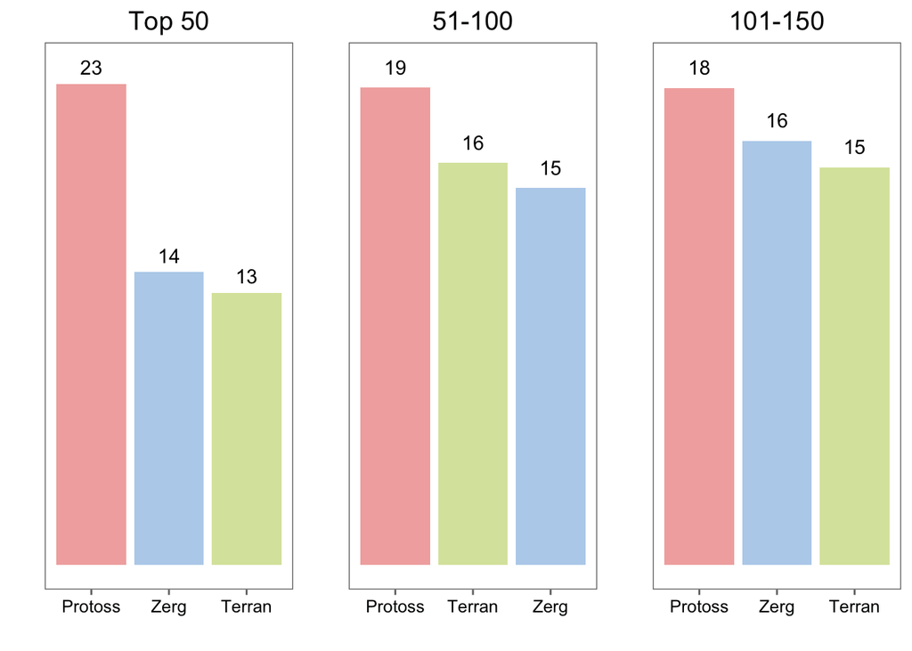

```r
grid.arrange(top50.plot, top51.100.plot, top101.150.plot, nrow = 1)
```

It looks like the number of terran and zerg are very close to eachother with Protoss leading most of the way.